# Markdown

Alireza Moradi

8/16/2019

# Analyzing damage on public health and economy

#### Caused by severe weather events

A brief abalysis on the amount of harm done by different severe weather events on public health and economic consequences.

The basic goal of this paper is to explore the NOAA Storm Database and answer some basic questions about severe weather events. The below analysis was run on a MacBook Pro, 2.9Ghz intel core i7 cpu, MacOs Mojave 10.14.6.

## Data Processing

Loading required packages and the data into R.

```r
library(R.utils)
library(data.table)
library(dplyr)
library(ggplot2)
```

```r
data <- fread("02_course-project-2_repdata-data-StormData.csv.bz2", sep = ",", header = T)
```

# Questions

### 1. Across the United States, which types of events are most harmful with respect to population health?

```r
fatalities <- data %>% select(EVTYPE,FATALITIES) %>% group_by(EVTYPE) %>% summarise(sum = sum(FATALITIES)) %>% arrange(-sum)
print(fatalities)
```

```
## # A tibble: 985 x 2
##    EVTYPE           sum
##    <chr>          <dbl>
##  1 TORNADO         5633
##  2 EXCESSIVE HEAT  1903
##  3 FLASH FLOOD      978
##  4 HEAT             937
##  5 LIGHTNING        816
##  6 TSTM WIND        504
##  7 FLOOD            470
##  8 RIP CURRENT      368
##  9 HIGH WIND        248
## 10 AVALANCHE        224
## # … with 975 more rows
```

Total number of fatalities caused by each type of Event.

```r
injuries <- data %>% select(EVTYPE,INJURIES) %>% group_by(EVTYPE) %>% summarise(sum = sum(INJURIES)) %>% arrange(-sum)
print(injuries)
```

```
## # A tibble: 985 x 2
##    EVTYPE              sum
##    <chr>             <dbl>
##  1 TORNADO           91346
##  2 TSTM WIND          6957
##  3 FLOOD              6789
##  4 EXCESSIVE HEAT     6525
##  5 LIGHTNING          5230
##  6 HEAT               2100
##  7 ICE STORM          1975
##  8 FLASH FLOOD        1777
##  9 THUNDERSTORM WIND  1488
## 10 HAIL               1361
## # … with 975 more rows
```

Total number of injuries caused by each type of Event.

### 2. Across the United States, which types of events have the greatest economic consequences?

```r
w <- function(k){
    for(EXP in k){
        if(toupper(EXP) == "K"){
            k <- as.numeric(10^3)
        }
        else if(toupper(EXP) == "M"){
            k <- as.numeric(10^6)
        }
        else if(toupper(EXP) == "B"){
            k <- as.numeric(10^9)
        }
        else if(toupper(EXP) == "H"){
            k <- as.numeric(10^2)
        }
        else if(EXP == "?" | EXP == "" | EXP == "-"){
            k <- as.numeric(0)
        }
        else{
            k <- as.numeric(0)
        }
    }
    k
}
data$PROPDMGEXP <- sapply(X = data$PROPDMGEXP,FUN = w,simplify = "array")
data$CROPDMGEXP <- sapply(X = data$CROPDMGEXP,FUN = w,simplify = "array")
data$PROPDMG <- data$PROPDMG * data$PROPDMGEXP
data$CROPDMG <- data$CROPDMG * data$CROPDMGEXP

temp <- data %>% group_by(EVTYPE) %>% summarise(sum = sum(PROPDMG,CROPDMG)) %>% arrange(-sum)
print(temp)
```

```
## # A tibble: 985 x 2
##    EVTYPE                     sum
##    <chr>                    <dbl>
##  1 FLOOD             150319678250
##  2 HURRICANE/TYPHOON  71913712800
##  3 TORNADO            57352113590
##  4 STORM SURGE        43323541000
##  5 HAIL               18758221670
##  6 FLASH FLOOD        17562128610
##  7 DROUGHT            15018672000
##  8 HURRICANE          14610229010
##  9 RIVER FLOOD        10148404500
## 10 ICE STORM           8967041310
## # … with 975 more rows
```

Total economy impact seperated by Events.

# Results

### Public Health Impact

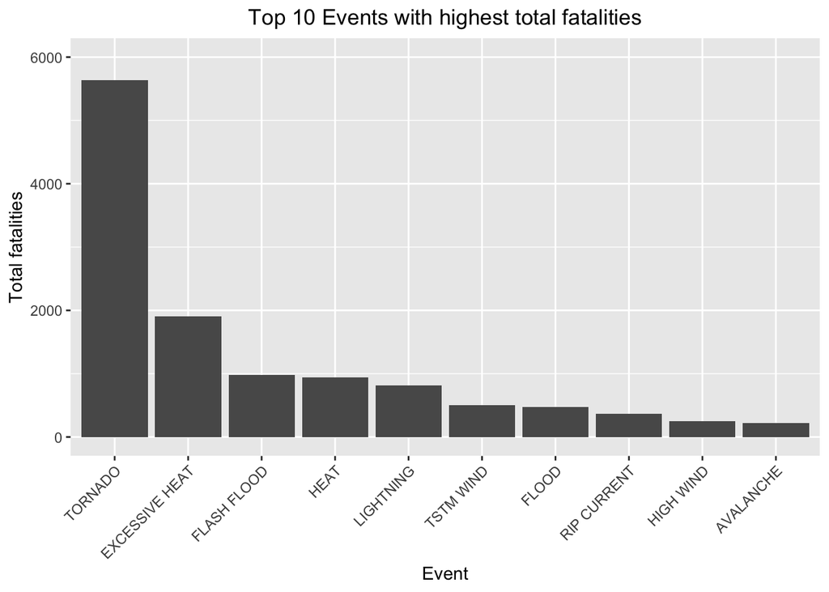

```r
g <- ggplot(fatalities[1:10,],aes(reorder(factor(EVTYPE),-sum),sum))
g <- g + geom_bar(stat = "identity") + ylim(c(0,6000))
g <- g + theme(axis.text.x = element_text(angle=45, vjust=1, hjust=1),plot.title = element_text(hjust = 0.5))
g <- g + labs(x = "Event",y = "Total fatalities",title = "Top 10 Events with highest total fatalities")
print(g)
```

According to the above plot, Tornado has the highest total fatalities followed by Excessive Heat and Flash Flood.

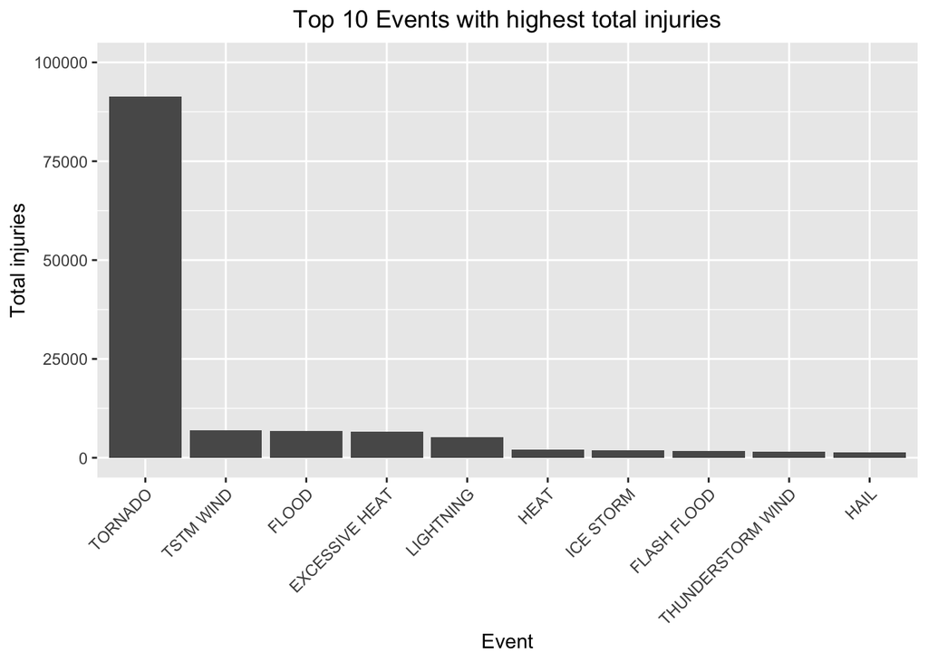

```r
g <- ggplot(injuries[1:10,],aes(reorder(factor(EVTYPE),-sum),sum))
g <- g + geom_bar(stat = "identity") + ylim(c(0,100000))
g <- g + theme(axis.text.x = element_text(angle=45, vjust=1, hjust=1),plot.title = element_text(hjust = 0.5))
g <- g + labs(x = "Event",y = "Total injuries",title = "Top 10 Events with highest total injuries")
print(g)
```

According to the above plot, Tornado caused around 91000 injuries which is the highest, Followed by TSTM Wind and FLood.

#### Conclusion

Tornado has the highest health impact altogether.

### Economy Impact

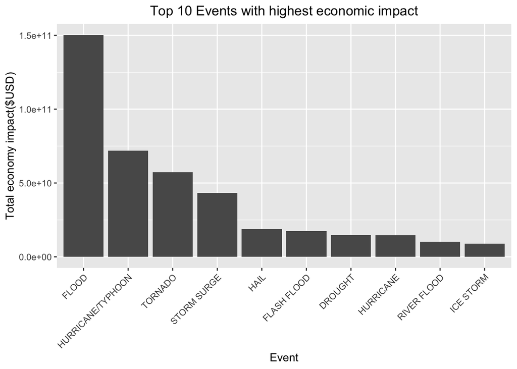

```r
g <- ggplot(temp[1:10,],aes(reorder(factor(EVTYPE),-sum),sum))
g <- g + geom_bar(stat = "identity")
g <- g + theme(axis.text.x = element_text(angle=45, vjust=1, hjust=1),plot.title = element_text(hjust = 0.5))
g <- g + labs(x = "Event",y = "Total economy impact($USD)",title = "Top 10 Events with highest economic impact")
print(g)
```

According to the above plot, Flood caused around “150 BILLION $” of damage, Which is the highest economy impact among all others.